# Notes

# Introductory Notes

This is not a textbook and it is not intend to be. Rather, it is short summary that emphases messages of lectures, gives corresponding references and reminds tasks (if any). During the course this note will be updated regularly.

### Students assesments

The final score are going to be estimated according a formula given below. Give your self a time to understand it:

```r
round(sum(min(6, sum(tasks, midExam, extraPoints)), goldenPoints, finalExam))
```

The variables are explained in more details:

- `tasks`: during the course you are going to have quite a number of tasks. I believe this is the main part of the course. The maximum sum of points is 4, but please note, that huge (unlimited) number of extra points can be received, if you demonstrate extra efforts in the tasks. In addition, please note that the `tasks` variable can be positive only if you supplied all the tasks that was required. If at least on of obligatory tasks are missing, the sum of total points are going to be 0. Thus, do all the tasks, event if the deadline is far over.
- `midExam`: in the middle of semester you are going to have mid exam. The possible outcome is 2 points.
- `extraPoints`: extra points are going to serve as system of encouraging. You can get extra points in many situations: taking challenges, answering unexpected question in lecture, giving good question and so on. Please note, that `extraPoints` can be negative as well. This could happen in the case of cheating (or something).
- `goldenPoints`: golden points are very similar to extra points, but to get those, you will have to put extra efforts in it. How to get them will be steaded in course.
- `finalExam` after the semester you are going to have final exam. The total points of the exam is 4.

**Cultural aspects of the course:**

1. During the course students are encourage to collaborate with each other. You can freely share thought, ideas and event source codes. In addition students can use all the material that can be found in the Internet or textbooks. Using the materials made by others are absolutely legal and have no negative side effect on your assesment. But there are two conditions that are strictly mandatory:
- You have to give all the credits to original source. Please write an explicit note with links and give some comments.
- You have to make sure you understand all the details of the code (or ideas) that you are using. You can be asked to comment it in great details. So, please use the material that you fully understand.
2. I am promise to do my best in answering all your question. You can ask freely during the lectures. Nevertheless, in practical assignments, your tasks is to try to find the answer by your self. So, in practical tasks, before asking any question please be prepare to report that efforts you have made to get the answer? For example: what has the Google query that you have used? That function you have already tried to apply?
3. Reading and assessing other students rapports is an important part of your learning. Please be honest to your colleagues and give the best insights. On the other hand, you should appreciate all the criticism that you get and accept it as important part of your learning.
4. Any initiative and communication is highly encouraged. Thus, If you have any ideas how to make course more productive or interesting, please let me know.
5. The tasks are always open for deeper analysis. If you have idea how to reveal topic in more detail please do it - it probably will get you some extra points. On the other hand, if you are not satisfied with the assignment that you get, you are free to give your reasons and negotiate.

# Chapter 1. Technical tools

## Technical requirements

In the course you are going to use tree main software:

- R - environment for statistical computing and graphics
- RStudio - a set of integrated tools designed to help you be more productive with R.
- Git - distributed version control system

I assume you already know R and how to install it. If not check the links below:

- [Installing R on Windows](https://www.youtube.com/watch?v=mfGFv-iB724&feature=youtu.be)
- [Installing R on Mac](https://www.youtube.com/watch?v=Icawuhf0Yqo&feature=youtu.be)
- [Installing R on Ubuntu (linux)](https://www.youtube.com/watch?v=P8wx4HY9me0)

In addition to R, it’s highly recommended that you install RStudio, which will make your experience with R much more enjoyable. If you need to install RStudio, you can do so [here](https://www.rstudio.com/products/rstudio/download/). Select the appropriate installer for your operating system.

Moreover, Git is also quite an important software. Git is a free and open source distributed version control system. It helps you not to get lost in versions of your project. In addition it is much easier to merge contributions among all team members and always have the newest version of the project. This is a system that professionals uses quite a lot (please admire it). Please visit [Git home](https://git-scm.com/) and install it in your system. Originally Git is command line program, on the other hand, Git might be used with graphical interface (GUI). Visit [Gits guis page](https://git-scm.com/downloads/guis) to select the one that looks best for you.

## Task 1. Rmd in Github

The goal of your first task is to get familiar Git.

1. Firstly, you have to sign up for [Github account](https://github.com/) and then create a repository under the name `Econometrics1`.
2. Write an email to me (Vygantas.Butkus@mii.vu.lt) with subject “[PE1] Link to Github”. And give the link to your Github account in the body.

Hint: A [short learning course on git](https://try.github.io/levels/1/challenges/1 could be useful. Please try it if you are not familial with Git. The deadline of this task is 2016-09-09 23:59.

## Task 2. Swirl course

Please visit [swirl](http://swirlstats.com/) website. Swirl is a frameworks for interactive R learning. Your task is to complete R programming course that can be find in my [GitHub account](https://github.com/1vbutkus/R_Programming).

For a first time, you have to install `swirl` package and the course material. Run R commands (be patient, this can take a while):

```r
install.packages(c('swirl', 'base64enc'))
library("swirl")
install_course_github("1vbutkus", "R_Programming")
```

To run a course you should type:

```r
library("swirl")
swirl()
```

Follow the instructions and select the “R Programming” course. Course contains 16 lessons. You have to do all of them. After each lesson you have to submit log code that will be generated by swirl. In addition, save the log code (just in case).

# Paskaita 1.

R atsitikinių dydžių generavimas

```r
x = rnorm(100000)
mean(x<=0)
```

```
## [1] 0.50012
```

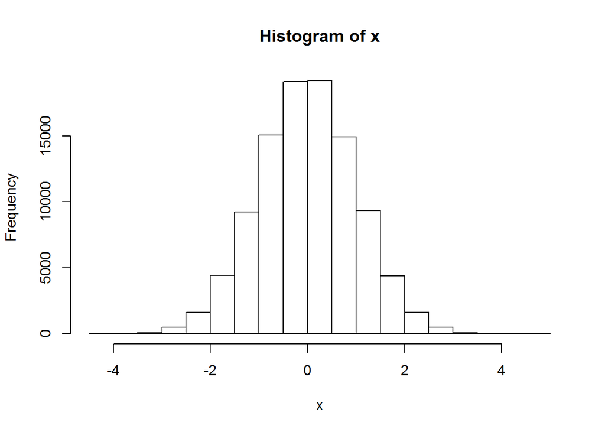

```r
hist(x)
```

Lošimo kauliukų ekspermentas

```r
experment <- function() sum(sample(1:6, 3, replace = TRUE)) > sum(sample(1:6, 2, replace = TRUE))
res = replicate(1000, experment())
mean(res)
```

```
## [1] 0.762
```

# Paskaita 2.

Pavyzdys paskaitoje. Nubrėšime grafiką, kaip įvykio pasirodymo vidurkis artėja į teorinę tikimybę.

```r
n = 1000
x = sample(0:1,n, replace = TRUE)

# skaiciuojame slenkancia suma - tai neefektyvus dudas, bet jis parodo skaiciavimo logika
S_bad = x * 0
S_bad[1] = x[1]
for(i in 2:n){
  S_bad[i] = S_bad[i-1] + x[i]
}

# efektyvus budas
S = cumsum(x)

# isitikinkime, kad abu budai duoda ta pati rezultata
all(S == S_bad)
```

```
## [1] TRUE
```

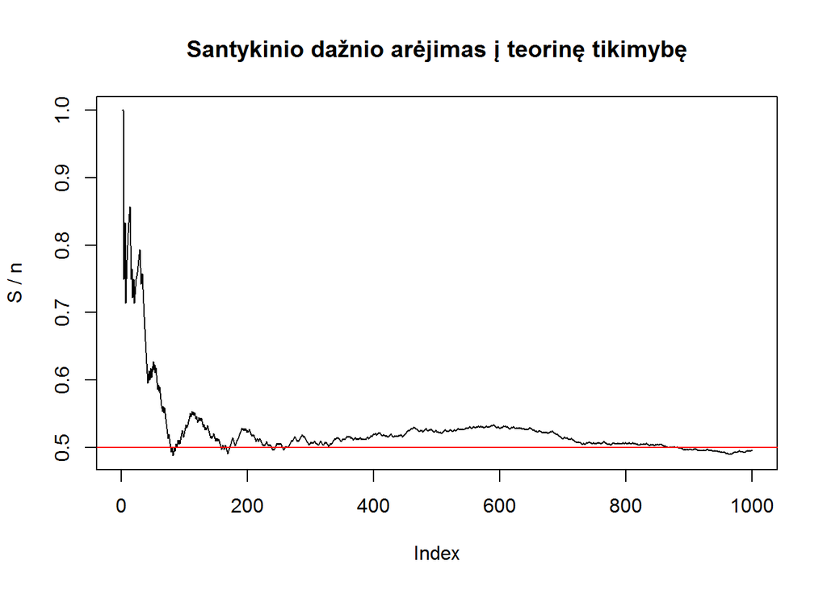

```r
# nubrezkime grafika
plot(S / 1:n, type="l", ylab = "S / n", main="Santykinio dažnio arėjimas į teorinę tikimybę")
abline(h=0.5, col=2)
```

## Task 3. Rmd in Github

The goal of your first task is to get familiar with R, Rmd files and Git.

1. I assume you already have github account with fresh repository `Econometrics1`. If not, go to task1.
2. Go to the Google and find some awesome R features, packages, programs, graphs or something. Pick anything that you think is worth noting.
3. In `Econometrics1` (in your account) create a subdirectory `task3` and in this subdirectory create Rmd file with title `task3.Rmd`. Then write a very short summary about the topic you have choose. Please be polite and give the link to original material. Try to put some R code snippets and visualization that describes the main essence of your note. Try to customize something (if possible). And finally make sure that the file can be knited.
4. Knit Rmd file. Make sure everything is OK.
5. Apply `add` command to include all related files. That include Rmd file, all pictures files and the final output file. Commit it to Git and push to Gith. Please note, that RStudio has small GUI for Git. It is available if you create a project (instead of plain Rmd file).
6. Please check in your github account if all files are uploaded.

Hint: A [short learning course on git](https://try.github.io/levels/1/challenges/1 could be useful. Please try it if you are not familial with Git.

Please note that those who demonstrate the greatest quality in their task will have actual opportunity to get their first extra points.

The deadline of this task is 2016-09-17 23:59.

## Task 4. Reading

Read (Kerns 2011, ch. 4) and make sure you understand everything.

## Task 5. Random variable challenge

Tarkime, kad ridenami trys taisyklingi standartiniai lošimo kauliukai. Fiksuojama iškritusių akučių suma, pažymėkime šį atsitiktinį dydį $S$.

1. Atlikite Monte-Carlo modeliavimą sugeneruodami $S$ atsitiktinio dydžio nepriklausomas realizacijas $S_1$, $S_2$, …, $S_n$. Čia $n=10^5$.
2. Raskite teorinį $S$ skirstinį, t.y. kiekvienai galimai $S$ reikšmei raskite pasirodymo tikimybę.
3. Iš sugeneruotos imties, padarykite santykinių dažnių lentelę ir gautas reikšmes palyginkite su teorinėmis tikimybėmis. Palyginimui pateikite grafiką ir lentelę, taip, kad būtų patogu lyginti gautus rezultatus.
4. Suskaičiuokite teorinį $S$ vidurkį ir dispersiją. Padarykite grafikus, kuriuose matytųsi, kaip didėjant $n$ minėtų charakteristikų įvertiniai artėja į teorines reikšmes.

The deadline of this task is 2016-09-25 23:59.

## Task 6. Swirl rezultatai

Aplanke `task6` yra failas `R_programing_swirlResults`. Jūsų užduotis padaryti rezultatų analizę. Rezultatas turi būti tvarkinga Rmd ataskaita su R kodais ir jūsų komentarais. Analizę galite daryti savo nuožiūrą, bet turite užtikrinti, kad bus išpildyti svarbiausi aspektai:

- Nuskaitykite duomenis. Užtikrinkite, kad duomenų tipai yra korektiški - jei ne, tai koreguokite. Ypatingą dėmesį atkreipkite į datas.
- Išvalykite masyvą nuo “šiukšlių”. Praktikoje retai, kada gaunamas pilnai sutvarkyti duomenys. Taip ir šį kartą, jums reikia išvalyti masyvą nuo galimų problemų. Pavyzdžiui:
  - ruošiant pateikties formą buvo testuojama ar viskas gerai veikia (reikia įdentifikuoti ir pašalinti šiuo irašus);
  - kai kas galėjo pakartotinai suvesti formas, taip atsirastu duomenų dubliavimas. Net jeigu dubliavimosi nėra, jums reikia tuo įsitikinti.
  - Visada gali būti ir kitų netikėtų problemų - verta pagalvoti.
- Susipažinimas su duomenimis. Jums reikia užtikrinti, kad suprantate ką reiškia kiekvienas stulpelis. Jeigu abejojate pabandykite padiskutuoti su kolegomis ir priimkite geriausią spėjimą.
- Jums reikia atsakyti į svarbiausius praktinius klausimus:
  - Kurie studentai yra pilnai atlikę visas swirl užduotis, t.y. pilnai atliktos visos užduotis nepraleidžiant jokių klausimų.
  - Reikia identifikuoti ir tuos, kurie ne pilnai viską atliko. Kiekvienam skolininkui reikia identifikuoti kiek pamokų yra nepilnai atsiskaitytą ir kiek klausimų yra praleista.
- Kiti įdomų klausimai (galite ir patys papildyti):
  - Kiek vidutiniškai užtrunka atlikti užduotis?
  - Ar galima pasitikėti žmonių deklaruojamų laiku? Žmonės kartu su forma pateikė ir kiek jų vertinimu užtruko atlikti užduotis, iš kitos pusės šią informaciją galima sulyginti su sistemoje fiksuojamas laikais (aišku tai gali kelti problemų - gali reikėti pasukti galvą kaip teisingai tai atlikti).
  - Kurios užduotys sunkiausios? (hint: tai galima spręsti ir pagal laiką, ir pagal klaidingus bandymus ir pagal praleidimų skaičių)

Užduoties atlikimo terminas 2016-10-02 23:59.

## Task 7.

Šios užduotys remiasi atsitiktinių skaičių generavimu. Jums reikia atlikti visas užduotis, kiekvienai užduočiai sukurkite po atskirą failą su atitinkamu pavadinimu (Kauliukai, Moneta, Rulete, CRT).

**Kauliukai.** Du žaidėjai žaidžia tokį žaidimą. Pirmasis žaidėjas meta tris kauliukus ir fikuoja iškritusių taškų sumą. Antrasis žaidėjas ridena du kauliukus ir skiačiuoja iškrituių taškų sumą. Laimi tas žaidėjas, kurio taškų suma yra didesnė. Jeigu taškų sumos yra lygios, tai, tai ekspermentas kartojamas iš naujo (ir taip kartojama tol, kol galiausiai nustatomas laimėtojas). Kokia tikimybė laimėti pirmajam žaidėjui?

**Moneta.** Tarkime metama moneta. Jeigu iškrenta herbas, tai laimite $12$ EUR. Jeigu skaičius, tai pralošiate $10$ EUR. Bus žaidžiama $100$ kartų ir gauti rezultatai sumuojami. Kokia tikimybė jums turėti teigiamą balansą po $100$ kartų? Koks balanso pasikliautinis $95%$ intervalas? Kaip atrodo balanso tankis?

**Rulete.** Nagrinėkime standartinę kazino ruletę. Kokia tikimybė, kad po $1000$ vienodų statymų ant vienos pasirinktos spalvos, bus teigiamas balansas? Raskite apytikslę $x$ reikšmę, kuriai galioja nelygybe $P(balansas<x) = 0.25$.

**CRT.** Generuojame $n$ atsitiktinių dydžių turinčių Beta skirstinį su parametrais $\alpha=\beta=0.5$ Iš šių atsitiktinių dydžių suskaičiuojamas aritmetinis vidurkis. Kaip atrodo aritmetinio vidurkio tankis, kai $n=100$?

Užduoties atlikimo terminas 2016-10-14 23:59.

# MC pavydžiai

Sugeneruokim atsitiktinius dydžius iš kurių galėtumėm įvertinti skaičių $\pi$.

```r
n = 100000
x = runif(n)
y = runif(n)

4*mean(x^2 + y^2 < 1)
```

```
## [1] 3.14652
```

Įvertinkime funkcijos $f(x) = \frac{\sin(x)}{x}$ apibrėžtinį integralą.

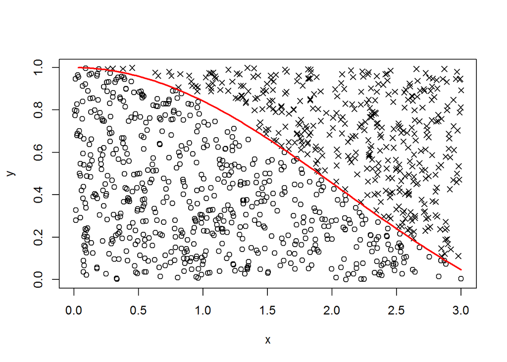

```r
n = 1000
f <- function(x) sin(x) / x
x = runif(n, 0, 3)
y = runif(n)

ind = f(x) > y
pch = ifelse(ind, 1, 4)
plot(x,y, pch=pch)
curve(f, 0, 3, ylim=0:1, add=TRUE, col=2, lwd=2)
```

```r
# atsakymas
3*mean(ind)
```

```
## [1] 1.815
```

```r
# patikrinam ar tikrai
integrate(f, 0, 3)
```

```
## 1.848653 with absolute error < 2.1e-14
```

Aritmetinio vidurkio tankis. Prisiminkite: jei aritmetinis vidurkis (žymesime $\bar{X}$) skaičiuojmats atsitiktiniams dydžiams, tai $\bar{X}$ taip pat tampa atsitiktiniu dydžiu (nes tai yra funkcija nuo atsitiktinių dydžių). Vadinasi, jei $\bar{X}$ yra atsitiktinis dydis, tai jis turi savo pasiskirstymo funkciją (ir tankį). Pažiūrėkimte kaip tai atrodo

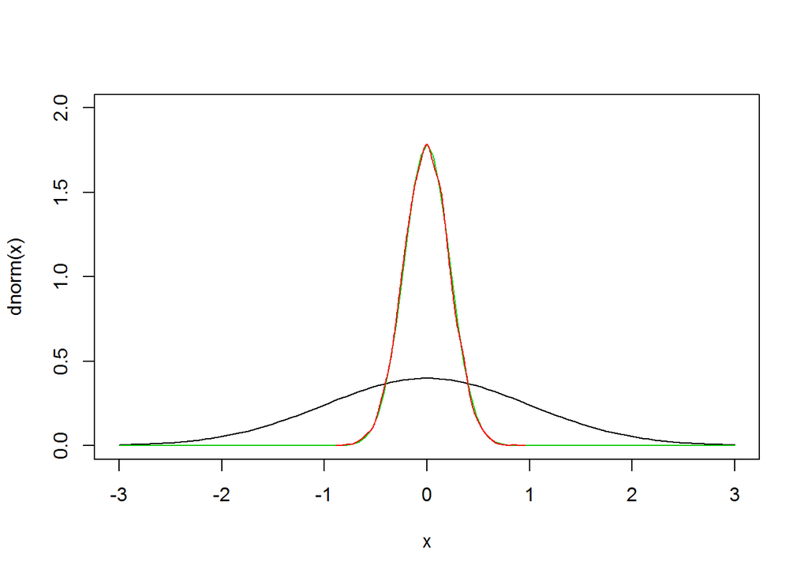

```r
n = 20

# imtis, kuria sudaro aritmetiniai vidurkiai
xbar = replicate(10000, mean(rnorm(n)))

curve(dnorm, -3, 3, ylim=c(0,2))
curve(dnorm(x, sd=sqrt(1/n)), -3, 3, ylim=c(0,2), add=TRUE, col=3)

lines(density(xbar), col=2)
```

## Task 9. Swirl tęsinys

Jūsų laukia naujos Swirl pamokos:

- https://github.com/1vbutkus/Data_Analysis_PE Šias pamokas reikia atlikti visas.
- https://github.com/1vbutkus/Statistical_Inference_PE Nereikia atlikti visų pamokų. Reikia tik Introduction, Probability1, Probability2 ConditionalProbability, Expectations, Variance, CommonDistros.

Noriu atkreipti dėmesį, kad pamokose yra nuorodos yra papildomus filmukus arba skaidres - tai nėra privaloma, nes didžiąją dalį tos pačios informacijos galima sužinoti pagrindinėje literatūroje. Visgi, jei jaučiate kad ne viską suprantate, tai tikrai verta pažiūrėti.

Taip pat noriu pranešti, kad visi studentai, kurie nepilnai atliko ankstesnes užduotis, arba atliko su `skip` pagalba, tai turi tas pamokas praeiti dar kartą ir dabar garbingai atsižymėti. Tikrai daugumai jūsų tai labai pravers. Juo labiau, kad tarpinis atsiskaitymas bus būtent iš swirl pateiktų klausimų.

Užduoties atlikimo terminas 2016-10-27 23:59.

## Task 10.

Užduotis skirta išmokti tikrinti paprastą statistinę hipotezę ir suprasti jos rezultatus.

1. Tegul $x_1, ..., X_{100} \sim N(1, 2)$. Susigeneruokite tokią imtį ir patikrinkite nulinę hipotezę, kad $H_0: \mu=1$, su alternatyva, kad $\mu\neq 1$. Tam rekalinga funkcija `t.test`. Detaliai paaiškinkite ką reiškia funkcijos išvestyje pateikti skaičiai.
2. Kartokite `a)` dalies generavima daug kartų (pvz.10^4) ir suskaičiuokite kiek atvejų buvo atmesta nulinė hipotezė? Išreiškite šį skaičių procentais. Kokią išvadą galite padaryti?

Užduoties atlikimo terminas 2016-11-04 23:59.

# Tiesinė regresija

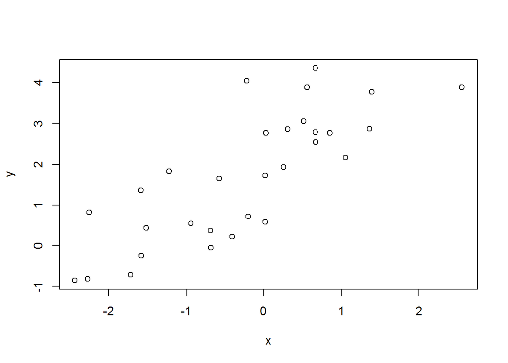

```r
x = rnorm(30)
y = 2 + 1*x + rnorm(30)
plot(x, y)
```

```r
# 1.
b1h = (mean(x*y) - mean(x)*mean(y)) / (mean(x^2) - mean(x)^2)

# 2.
LF <- function(par) sum((y - par[1] - par[2]*x)^2)
optim(c(0,0), LF)
```

```
## $par
## [1] 1.964864 1.027931
##
## $value
## [1] 26.00569
##
## $counts
## function gradient
##       65       NA
##
## $convergence
## [1] 0
##
## $message
## NULL
```

```r
# 3. Matricine forma
X = cbind(1, x)
solve(t(X)%*%X)%*%t(X)%*%y
```

```
##       [,1]
##   1.965055
## x 1.027964
```

```r
# 4.
lm(y~x)
```

```
##
## Call:
## lm(formula = y ~ x)
##
## Coefficients:
## (Intercept)            x
##       1.965        1.028
```

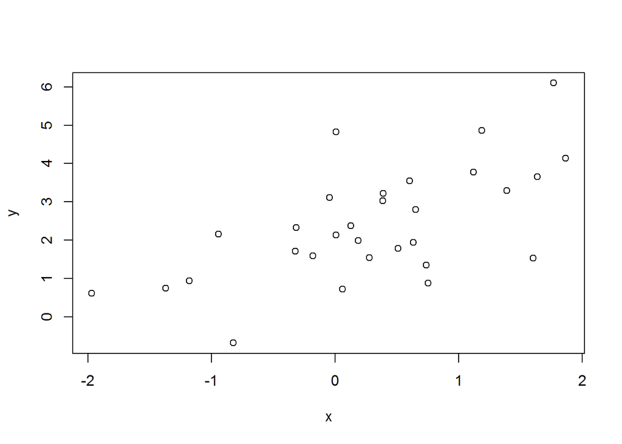

```r
x = rnorm(30)
y = 2 + 1*x + rnorm(30)
plot(x, y)
```

```r
mod = lm(y~x)
summary(mod)
```

```
##
## Call:
## lm(formula = y ~ x)
##
## Residuals:
##      Min       1Q   Median       3Q      Max
## -2.15720 -0.67728 -0.00085  0.55539  2.69828
##
## Coefficients:
##             Estimate Std. Error t value Pr(>|t|)
## (Intercept)   2.1134     0.2241   9.433 3.44e-10 ***
## x             0.9801     0.2302   4.257  0.00021 ***
## ---
## Signif. codes:  0 '***' 0.001 '**' 0.01 '*' 0.05 '.' 0.1 ' ' 1
##
## Residual standard error: 1.171 on 28 degrees of freedom
## Multiple R-squared:  0.3929, Adjusted R-squared:  0.3712
## F-statistic: 18.12 on 1 and 28 DF,  p-value: 0.0002103
```

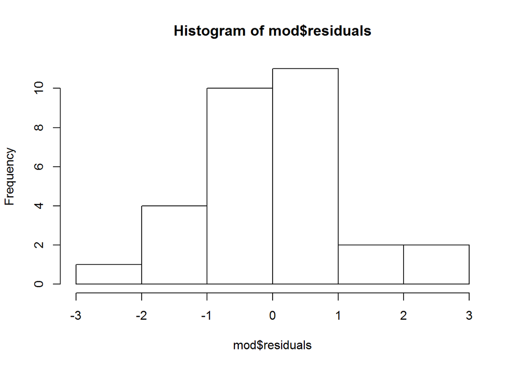

```r
hist(mod$residuals)
```

```r
newx = rnorm(5)

mod$coefficients[1] + mod$coefficients[2]*newx
```

```
## [1] 1.619859 1.657121 3.283338 5.375533 2.930606
```

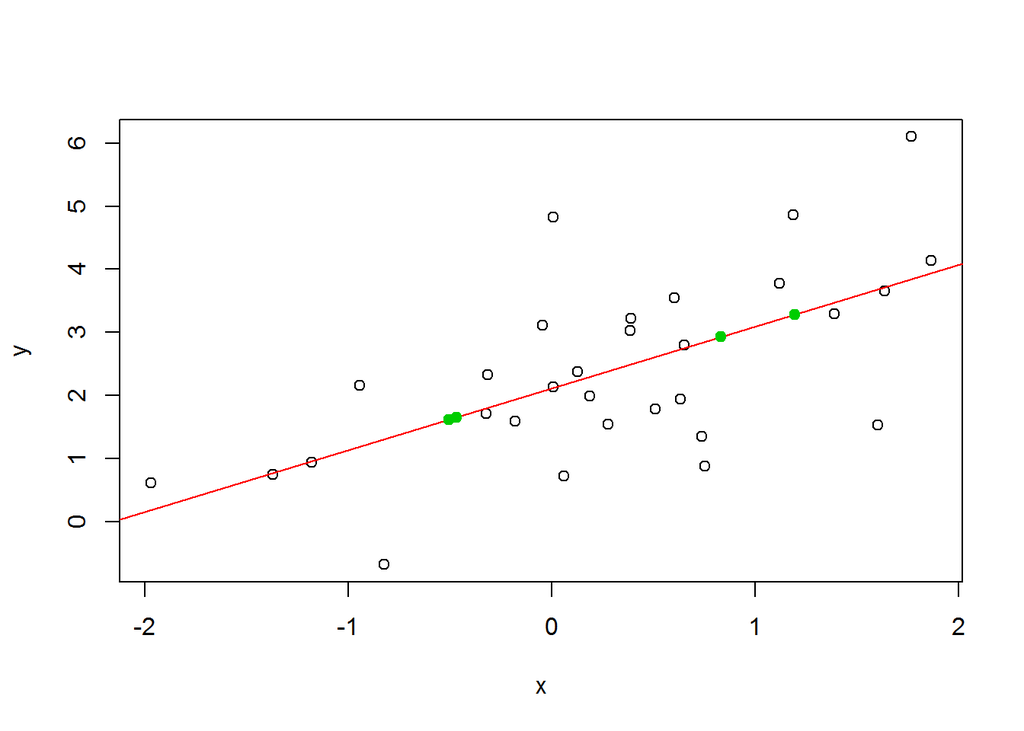

```r
newy = predict(mod, newdata=data.frame(x=newx))

plot(x,y)
abline(mod, col=2)
points(newx, newy, col=3, pch=19)
```

## Task 11.

Pakete `datasets` yra duomenų masyvas `longley`. Iš šio kintamųjų padarykite tiesinę regresiją, kur prognozuojamas kintamasis būtų `GNP`, o regresosius `Employed`. Jums reikia:

1. Įvertinti paprastosios tiesinės regresijos modelį. Pateikti modelio `summary` ir pakomentuoti ką reiškia gauti skaičiai. Kaip interpretuoti gautus rezultatus?
2. Padarykite modelio prognozes taškuose $62, 65, 68$.
3. Išbrėžkite kintamųjų sklaidos diagramą kartu su tiesinės regresijos tiese ir naujomis prognozėmis. Grafiką pateikite su pilna legena, kurioje būtų nurodyti visi žymėjimai.

Užduoties atlikimo terminas 2016-11-11 23:59.

## Task 12. (Atnaujinta)

Jūs turite patikrinti savo kolegų darbus. Faile `Studentai.xlsx` yra paskirstyta kuriuos darbus reikia tikrinti. Tikrinimo vertinimus turite sukelti į internetinę formą adresu:

https://docs.google.com/forms/d/e/1FAIpQLSfU3pHAgrXh4oIBkSu_MmN037vCnhWC7p5HUfH6t3oX56utEA/viewform

Atkreipiu dėmesį, kad formoje užduočių sąrašas pailgėjo. Dabar jame turi būti visi darbai, kuriuos reikės tikrinti.

Kai ištikrinsite kolegų darbus, turite taip pat patikrinti ir užpidyti savo darbus. Jeigu darbe buvo klaidų - būkite sau kritiški ir pademonstruokite, kad kažką išmokote išvardindami savo klaidas.

Užduoties atlikimo terminas 2016-12-08 23:59.

## Pranešimas

Visos naujos užduotys bus formuluojamos virtualioje mokymosi aplinkoje (VMA). Prašau visus apsilankyti ir atlikti paskirtas užduotis.

## Lygties sprendimas sveikaisiais skaičiais

Reikia išspręsti lygti

$$xy = x + y + 5$$

sveikaisias skaičiais.

Sprendimas labai paprastas patikrinant visus variantus intervale $x \in [-20,20]$

```r
x = -20:20
y = (x+5)/(x-1)
ind = y%%1 == 0
ind[is.na(ind)] = FALSE
paste("x=",x[ind],"; y=", y[ind], sep="")
```

```
## [1] "x=-5; y=0"  "x=-2; y=-1" "x=-1; y=-2" "x=0; y=-5"  "x=2; y=7"
## [6] "x=3; y=4"   "x=4; y=3"   "x=7; y=2"
```

Gavus sprendinius dar reikia įsitikinti, kad daugiau sprendinių nėra. Isitikinti padeda toks grafikas:

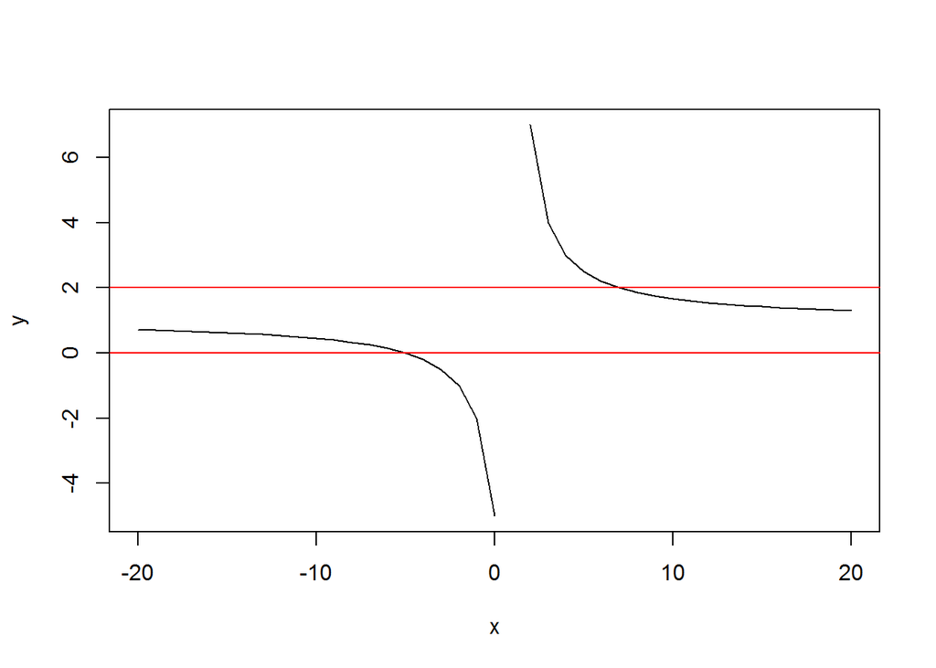

```r
plot(x,y,type="l")
abline(h=2, col=2)
abline(h=0, col=2)
```

Tolimesni $y$ sprendiniai yra intervale $(0, 2)$. Vienintelis sveikasis skaičius šiame intervale yra $1$. Bet kai $y=1$, tai sprendinys neegzistuoja.

# Fiktyvūs kintamieji

Pirmas pvz.:

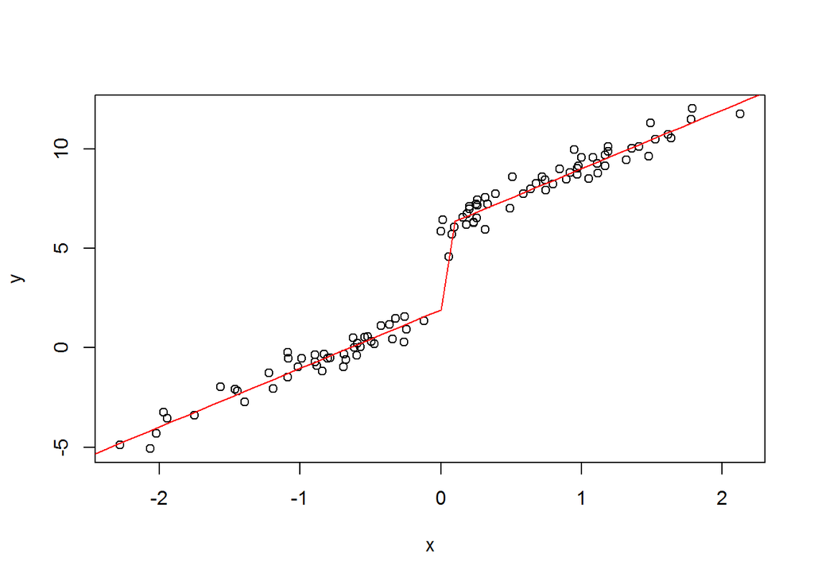

```r
n = 100
x = rnorm(n)
y = 2 + 3*x + rnorm(n, sd=0.5)
y[x>0] = y[x>0] + 4

### apsimetame, kad nezinome
plot(x ,y)

d = (x>0)*1

mod = lm(y~x+d)

newx = seq(-3, 3, by=0.1)
df = data.frame(x=newx, d=1*(newx>0))
df['ypred'] = predict(mod, df)
lines(df$x, df$ypred, col=2)
```

```r
summary(mod)
```

```
##
## Call:
## lm(formula = y ~ x + d)
##
## Residuals:
##      Min       1Q   Median       3Q      Max
## -1.64472 -0.29948 -0.00877  0.33045  1.11702
##
## Coefficients:
##             Estimate Std. Error t value Pr(>|t|)
## (Intercept)  1.90509    0.11106   17.15   <2e-16 ***
## x            2.94219    0.08962   32.83   <2e-16 ***
## d            4.16064    0.18249   22.80   <2e-16 ***
## ---
## Signif. codes:  0 '***' 0.001 '**' 0.01 '*' 0.05 '.' 0.1 ' ' 1
##
## Residual standard error: 0.4871 on 97 degrees of freedom
## Multiple R-squared:  0.9903, Adjusted R-squared:  0.9901
## F-statistic:  4945 on 2 and 97 DF,  p-value: < 2.2e-16
```

Pirmo pavyzdžio alternatyva

```r
mod = lm(y~x+I(x>0))

newx = seq(-3, 3, by=0.1)
df = data.frame(x=newx)
df['ypred'] = predict(mod, df)
```

Antras pavyzdys

```r
n = 1000
x = rnorm(n)

# teisiog lygtis
y = 3*x + rnorm(n, sd=0.5)

# sukuriam kategorini kintamaji
s = factor(sample(c('LT', 'LV', 'EE'), size = n, replace = TRUE), levels=c("LT", "LV", "EE"))

# padarome pastumius
y[s=='LT'] = y[s=='LT'] + 1
y[s=='LV'] = y[s=='LV'] + 2
y[s=='EE'] = y[s=='EE'] + 3

# standartinis vertinimas
lm(y~x + s)
```

```
##
## Call:
## lm(formula = y ~ x + s)
##
## Coefficients:
## (Intercept)            x          sLV          sEE
##      1.0241       3.0025       0.9831       1.9257
```

```r
# individualus (bet analogiskas) vertinimas
lm(y ~ x + I((s=='LT')*1) + I((s=='LV')*1) + I((s=='EE')*1) - 1)
```

```
##
## Call:
## lm(formula = y ~ x + I((s == "LT") * 1) + I((s == "LV") * 1) +
##     I((s == "EE") * 1) - 1)
##
## Coefficients:
##                  x  I((s == "LT") * 1)  I((s == "LV") * 1)
##              3.002               1.024               2.007
## I((s == "EE") * 1)
##              2.950
```

# References

Kerns, G. Jay. 2011. “Introduction to Probability and Statistics Using R.”